# Adult

#### Feature: Native country

Number of missing values is 583, in percentage 1.7904856.

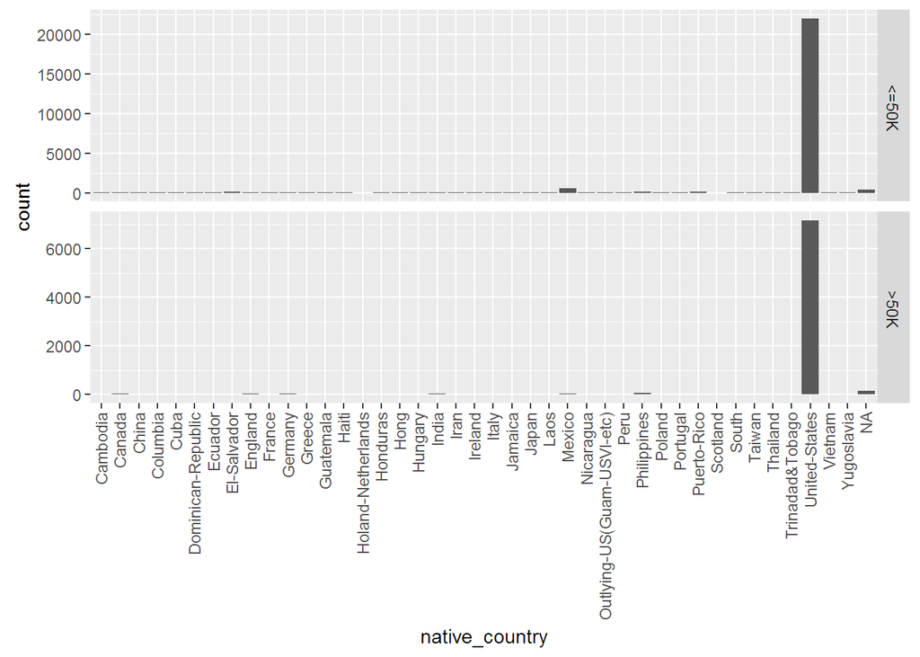

Percentage of native countries (nr of persons):

| Country | Nr | Percent |
| --- | --- | --- |
| United-States | 29170 | 89.59 |
| Mexico | 643 | 1.975 |
| NA | 583 | 1.79 |
| Philippines | 198 | 0.6081 |
| Germany | 137 | 0.4207 |
| Canada | 121 | 0.3716 |
| Puerto-Rico | 114 | 0.3501 |
| El-Salvador | 106 | 0.3255 |
| India | 100 | 0.3071 |
| Cuba | 95 | 0.2918 |

##### Checking workclass and occupation NA-s

Workclass and Occupation have very similar number of NAs. The recors with NAs are the same in 0.999785%.

# Feature transformation

Decisions: - introducing new category for workclass and occupation NAs: UNKNOWN both in test and training/evaluation sets, - removing all remaining NAs from training/evaluation set, - removing 90-year-old observations. - removing capital gain of 99,999, - removing weekly working hous of 84 or more.

Transformations above means 3% data loss.

# Model building and selection

After the modifications above I divided the training dataset into a training and a validation set.

I chose **Random Forest** and **GBM** methods.I used H20 for procesing. set.seed(73)

# Results

Table continues below

| Model | MSE | AUC_validation | AUC_training |
| --- | --- | --- | --- |
| Random Forest | 0.104770186607126 | 0.915387236503315 | 0.915387236503315 |
| GBM | 0.0485329711930138 | 0.923605417174624 | 0.984515151459697 |

| AUC_test |
| --- |
| 0.915540115129116 |
| 0.921648291863314 |

**Confusion matrix of Random Forest**

|  | <=50K | >50K | Error | Rate |
| --- | --- | --- | --- | --- |
| **<=50K** | 14356 | 1694 | 0.1055 | =1694/16050 |
| **>50K** | 1363 | 3744 | 0.2669 | =1363/5107 |
| **Totals** | 15719 | 5438 | 0.1445 | =3057/21157 |

**Confusion matrix of GBM**

|  | <=50K | >50K | Error | Rate |
| --- | --- | --- | --- | --- |
| **<=50K** | 15269 | 781 | 0.04866 | =781/16050 |
| **>50K** | 484 | 4623 | 0.09477 | =484/5107 |
| **Totals** | 15753 | 5404 | 0.05979 | =1265/21157 |

**Tompa, Miklós**